# PEP Access

Malavika Rajeev

6/25/2018

## Background

### Data overall

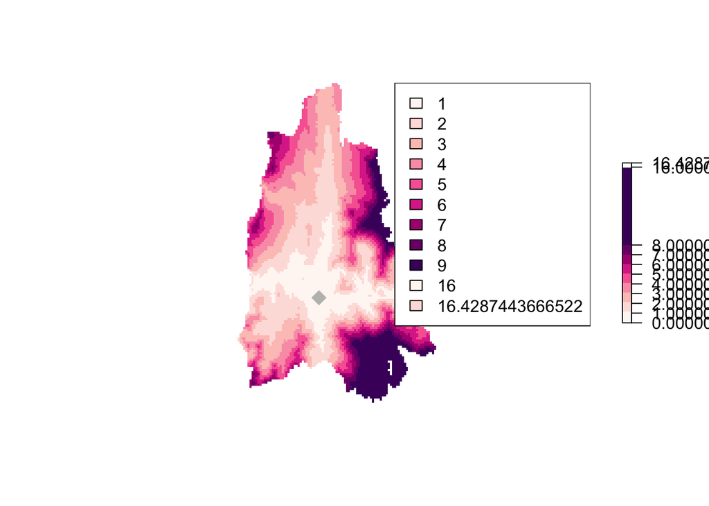

```r
## Summary stats
monthly.bites <-rowSums(exposure.mat)/ncol(exposure.mat)
moramanga$commune.midpops <- moramanga$pop2015adj + (moramanga$pop2020adj - moramanga$pop2015adj)/2
moramanga$monthly.bites <- monthly.bites[match(moramanga$commune, names(monthly.bites))]
moramanga$monthly.incidence <- moramanga$monthly.bites/moramanga$commune.midpops*1e5
# distance!

## travel time layer
travel.times <- raster("output/study.area.accessibility.tif")
mora.access <- mask(travel.times, moramanga)
mora.access <- crop(mora.access, moramanga)
moramanga <- raster::extract(mora.access, moramanga, fun = mean, na.rm=TRUE, df = TRUE, sp = TRUE)
moramanga$comm.long <- coordinates(moramanga)[,1]
moramanga$comm.lat <- coordinates(moramanga)[,2]

# plot it
plot(mora.access/60,
     breaks = c(0, 1, 2, 3, 4, 5, 6, 7,8, 16, max(values(mora.access)/60, na.rm = TRUE)),
     col = c("#fff7f3", "#fde0dd", "#fcc5c0", "#fa9fb5", "#f768a1", "#dd3497",
             "#ae017e", "#7a0177", "#49006a"), axes = FALSE, box = FALSE)
points(moramanga$comm.long[moramanga$commune == "Moramanga"], moramanga$comm.lat[moramanga$commune == "Moramanga"], pch = 18, col = "grey", cex = 2)
legend("topright", legend = c(1, 2, 3, 4, 5, 6, 7, 8, 9, 16, max(values(mora.access)/60, na.rm = TRUE)), fill = c("#fff7f3", "#fde0dd", "#fcc5c0", "#fa9fb5", "#f768a1", "#dd3497",
             "#ae017e", "#7a0177", "#49006a"))
```

```r
# correlation checks (need to add in distance and proportion of pop within x km/hrs)
library(GGally)
```

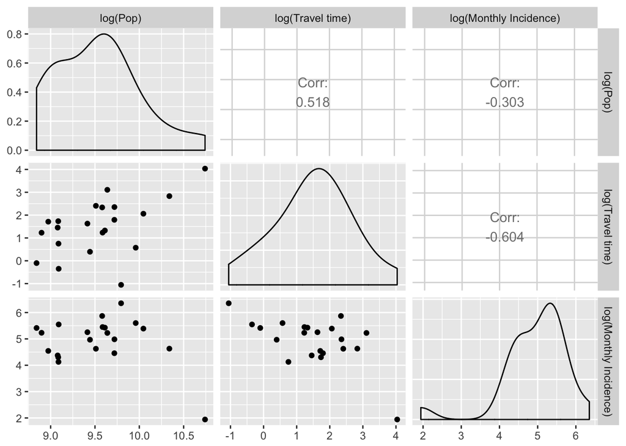

```r
#kable(cor(moramanga@data[,colnames(moramanga@data) %in% c("commune.midpops", "study.area.accessibility", "monthly.incidence")]))
ggpairs(log(moramanga@data[,colnames(moramanga@data) %in% c("commune.midpops", "study.area.accessibility", "monthly.incidence")]), columnLabels = c("log(Pop)", "log(Travel time)", "log(Monthly Incidence)"))
```

```r
#splom(log(moramanga@data[,colnames(moramanga@data) %in% c("commune.midpops", "study.area.accessibility", "monthly.incidence")]), type=c('p','r'))
```

## Empirical estimates of p_report

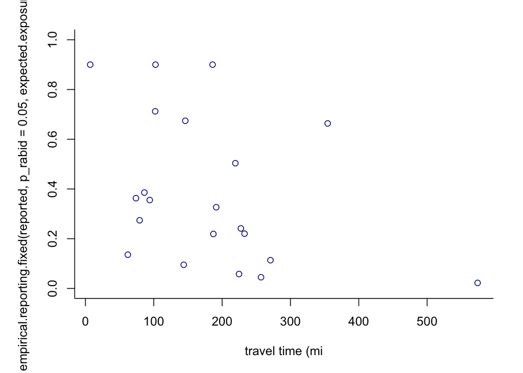

```r
exposures.per100k.dogs.high <- 1000*0.39
exposures.per100k.dogs.low <- 600*0.39

hdr.high <- 25
hdr.low <- 5

expected.exposures.high <- moramanga$commune.midpops/hdr.low/1e5*exposures.per100k.dogs.high # annual bites assuming low HDR and high exposures
expected.exposures.low <- moramanga$commune.midpops/hdr.high/1e5*exposures.per100k.dogs.low # annual bites assuming high HDR and low exposures
expected.exposures.mid <- (expected.exposures.high + expected.exposures.low)/2
# middle of the road estimate of incidence

reported <- moramanga$monthly.bites*12

p_rabid_max_low <- expected.exposures.low/reported*0.95
p_rabid_max_high <- expected.exposures.high/reported*0.95
p_rabid_max_low[p_rabid_max_low >= 1] <- 1
p_rabid_max_high[p_rabid_max_high > 1] <- 1

empirical.reporting.fixed <- function (bites, p_rabid = 0.2, expected) {
    p_rabid_max = expected/bites*0.9
    p_rabid_max[p_rabid_max >= p_rabid] <- p_rabid
    p_report <- bites*p_rabid_max/expected
    return(p_report)
}

par(mfrow = c(1, 1), mar = c(5, 5, 2,  2))
plot(moramanga$study.area.accessibility, empirical.reporting.fixed(reported, p_rabid = 0.05, expected.exposures.low),
     ylim = c(0, 1), bty = "l", col = "darkblue", xlab = "travel time (mi") # best case
```

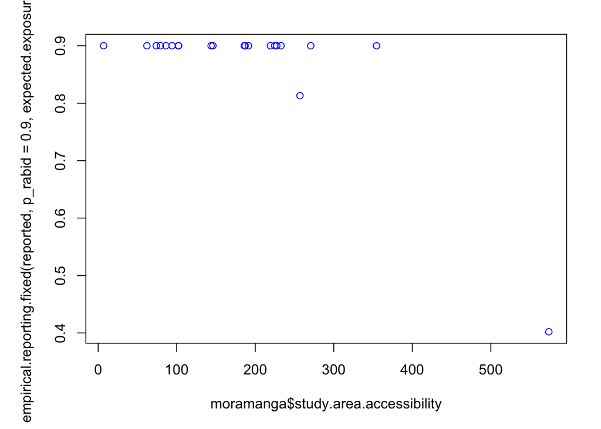

```r
plot(moramanga$study.area.accessibility, empirical.reporting.fixed(reported, p_rabid = 0.9, expected.exposures.low),
       col = "blue") # worst case
```

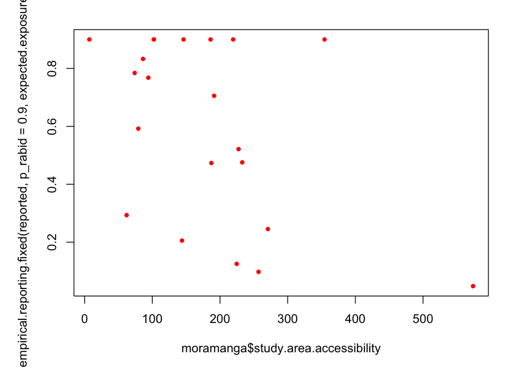

```r
plot(moramanga$study.area.accessibility, empirical.reporting.fixed(reported, p_rabid = 0.9, expected.exposures.high),
       col = "red", pch = 20) # middle of the ground scenario
```

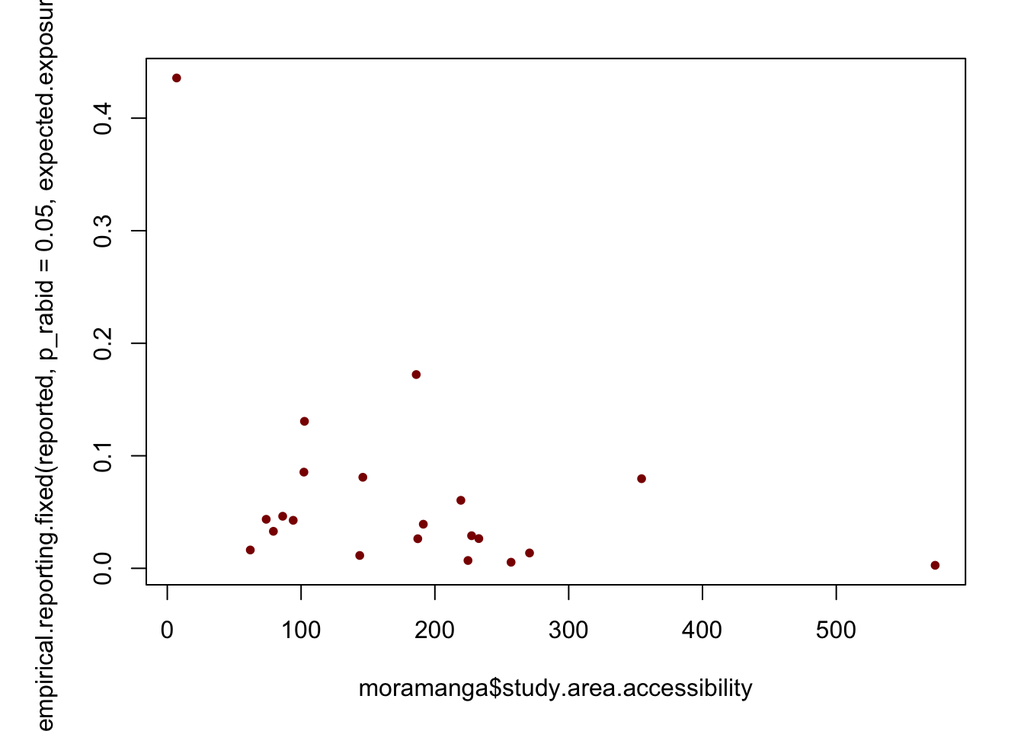

```r
plot(moramanga$study.area.accessibility, empirical.reporting.fixed(reported, p_rabid = 0.05, expected.exposures.high),
       col = "darkred", pch = 20) # worst case
```

```r
# legend("topright", bty = "n", legend = c("Low exposures + low p_rabid", "Low exposures + high p_rabid",
                    # "High exposures + high p_rabid", "High exposures + low p_rabid"),
       # col = c("darkblue", "blue", "red", "darkred"), pch = 20)
```

Here we attempt to disentagle these factors by estimating the relationship between travel time to a clinic and reporting rates based on assumptions of dog rabies incidence and background levels of non-rabid bites.

We constrain incidence of human exposures based on estimates of human exposures per 100,000 dogs in a no-vaccination scenario generated by Hampson et al. 2018. We then set upper and lower bounds on the human:dog ratio (between 5 people per dog to 25 people per dog) to get the maximum and minimum expected annual bites per 100,000 people for each commune.

We then fit a model to our reported bite data (annual reported bites by commune) where bite incidence is predicted by population size, but only within a plausible range of incidences by estimating a scaling factor of incidence with population size. We also assume that background incidence of reported non-rabid dog bites increase with population size (Hampson et al. 2018, Figure 2). Then we estimate the incidence scaling factor by population size, the relationship between travel time and the reporting rate, and the relationship between population size and the proportion rabid, such that:

```r
## model
tt.model <- "model {
  # reported bites
    for (j in 1:nlocs){
        # Number of bites
        bites[j] ~ dpois(rabid[j]*rho[j]/p_rabid[j] + B_0)
    }

  # spatial effects
  for (g in 1:nlocs){
    # Spatial random effect
    loc_eff[g] ~ dnorm(0, tau_loc)

    # Reporting in place g
    logit(rho[g]) <- B_tt*(1/ttimes[g]) + loc_eff[g]

    # Incidence avg in place g
    scaling.factor[g] <- B_pop*pop[g]
    rabid[g] <- scaling.factor[g]*expected.mean[g]

    # Background avg in place g
    logit(p_rabid[g]) <- B_prop*pop[g]
  }

  tau_loc <- 1/sd

  # priors
  B_tt ~ dnorm(0, 0.1)
  sd ~ dunif(0, 100)
  B_pop ~ dunif(B_pop.min, B_pop.max)
  B_prop ~ dnorm(0, 0.1)
  B_0 ~ dnorm(0, 0.1)
}"
```

And we set it so that we get the most conservative estimates of the relationship between reporting and travel times (i.e. taking out the maximum observed impact of pop on incidence)

```r
mora.bites <- merge(moramanga@data, exposure.mat, by.x = "commune", by.y = "row.names")
pop <- moramanga$commune.midpops
bites <- round(moramanga$monthly.bites*12)
ttimes <- mora.bites$study.area.accessibility/60
max.sf <- (expected.exposures.high/expected.exposures.mid)[1] # upper constraint of scaling factor
min.sf <- (expected.exposures.low/expected.exposures.mid)[1] # lower constraint of scaling factor
B_pop.max <- min(max.sf/pop)
B_pop.max*pop > max.sf # check to see if max good
```

```
##  [1] FALSE FALSE FALSE FALSE FALSE FALSE FALSE FALSE FALSE FALSE FALSE
## [12] FALSE FALSE FALSE FALSE FALSE FALSE FALSE FALSE FALSE FALSE
```

```r
B_pop.min <- max(min.sf/pop)
B_pop.min*pop < min.sf # check to see if min is good
```

```
##  [1] FALSE FALSE FALSE FALSE FALSE FALSE FALSE FALSE FALSE FALSE FALSE
## [12] FALSE FALSE FALSE FALSE FALSE FALSE FALSE FALSE FALSE FALSE
```

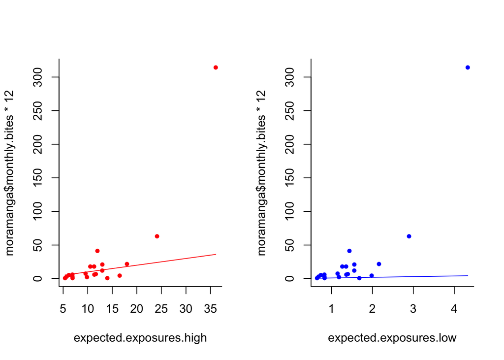

```r
## expected to observed
par(mfrow = c(1, 2))
plot(expected.exposures.high, moramanga$monthly.bites*12, col = "red", bty = "l", pch = 20)
lines(expected.exposures.high, expected.exposures.high, col = "red")
plot(expected.exposures.low, moramanga$monthly.bites*12, col = "blue", bty = "l", pch = 20)
lines(expected.exposures.low, expected.exposures.low, col = "blue")
```

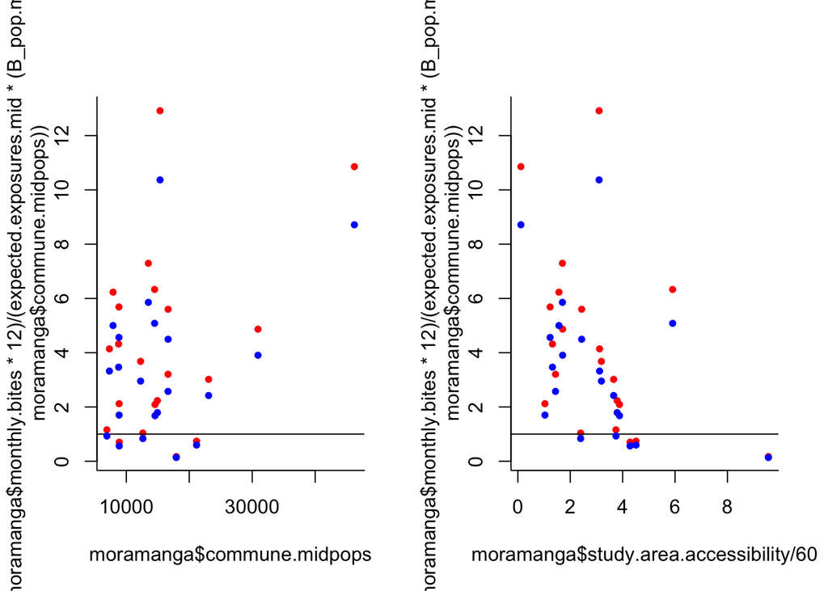

```r
plot(moramanga$commune.midpops,
     (moramanga$monthly.bites*12)/(expected.exposures.mid*(B_pop.min*moramanga$commune.midpops)),
      col = "red", bty = "l", pch = 20)
abline(h = 1)
points(moramanga$commune.midpops,
       moramanga$monthly.bites*12/(expected.exposures.mid*(B_pop.max*moramanga$commune.midpops)),
       col = "blue", pch = 20)

plot(moramanga$study.area.accessibility/60,
     (moramanga$monthly.bites*12)/(expected.exposures.mid*(B_pop.min*moramanga$commune.midpops)),
      col = "red", bty = "l", pch = 20)
abline(h = 1)
points(moramanga$study.area.accessibility/60,
       moramanga$monthly.bites*12/(expected.exposures.mid*(B_pop.max*moramanga$commune.midpops)),
       col = "blue", pch = 20)
```

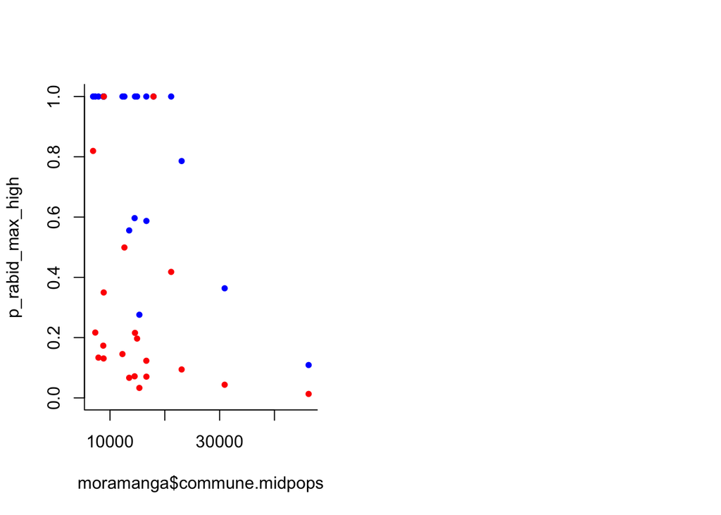

```r
## maximums
plot(moramanga$commune.midpops, p_rabid_max_high, bty = "l", pch = 20,
     ylim = c(0,1), col = "blue") # low incidence
points(moramanga$commune.midpops, p_rabid_max_low, col = "red", pch = 20) # high incidence
```

```r
## potential relationship between reporting and travelt
## data
nlocs = length(bites)

data <- list (bites = bites, pop = moramanga$commune.midpops,
              expected.mean = expected.exposures.mid,
              B_pop.min = B_pop.min, B_pop.max = B_pop.max,
              ttimes = ttimes, nlocs = nlocs)

inits <- list(B_tt = rnorm(1, 0, 1e-6), sd = 5,
              B_pop = rnorm(1, (B_pop.max + B_pop.min)/2, 1e-6),
              B_prop = rnorm(1, 0, 1e-6),
              B_0 = rnorm(1, 0, 1e-6))

jags_mod <- jags.model(textConnection(tt.model), data = data, inits = inits, n.chains = 5,
                       n.adapt = 1000)
params <- c("B_tt", "sd", "B_pop", "B_prop", "B_0")

samps <- coda.samples(jags_mod, params, n.iter = 10000)
burn.in <- 5000
check <- summary(window(samps, start = burn.in))
check
```

```
##
## Iterations = 5000:11000
## Thinning interval = 1
## Number of chains = 5
## Sample size per chain = 6001
##
## 1. Empirical mean and standard deviation for each variable,
##    plus standard error of the mean:
##
##              Mean        SD  Naive SE Time-series SE
## B_0     1.783e+00 7.658e-01 4.421e-03      1.769e-02
## B_pop   3.504e-05 2.196e-06 1.268e-08      4.027e-08
## B_prop -1.192e-04 1.623e-05 9.372e-08      2.084e-06
## B_tt    7.340e-01 9.821e-01 5.669e-03      7.348e-02
## sd      2.396e+01 1.890e+01 1.091e-01      6.006e-01
##
## 2. Quantiles for each variable:
##
##              2.5%        25%        50%        75%      97.5%
## B_0     4.047e-01  1.241e+00  1.749e+00  2.285e+00  3.375e+00
## B_pop   3.122e-05  3.316e-05  3.515e-05  3.696e-05  3.846e-05
## B_prop -1.485e-04 -1.308e-04 -1.201e-04 -1.083e-04 -8.512e-05
## B_tt   -7.423e-01  8.139e-02  5.652e-01  1.190e+00  3.240e+00
## sd      5.042e+00  1.093e+01  1.760e+01  3.017e+01  7.967e+01
```

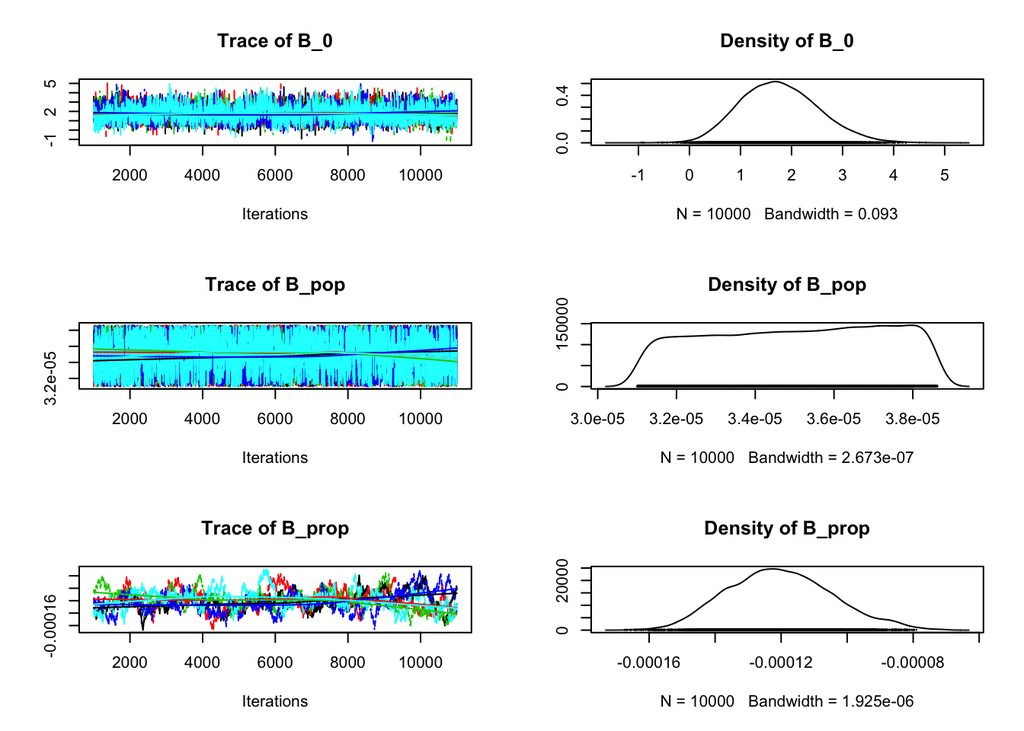

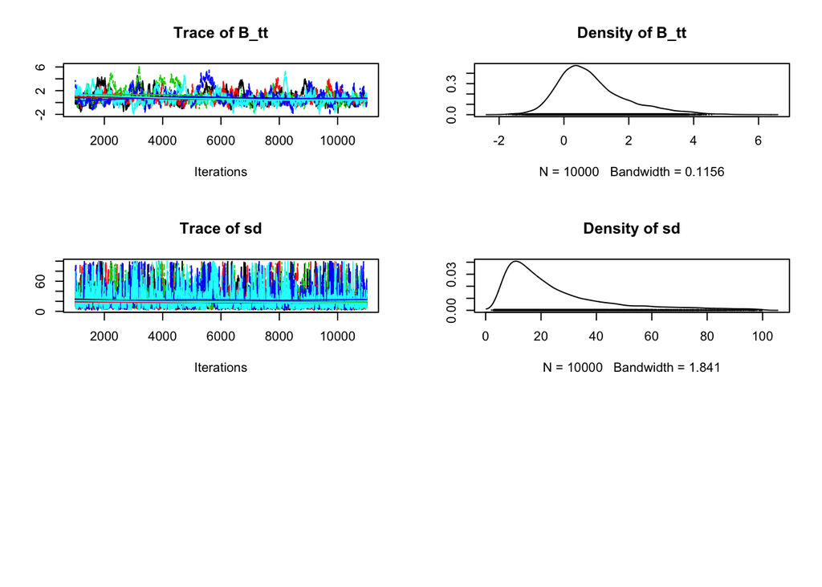

```r
plot(samps)
```

```r
# gelman.plot(samps)
gelman.diag(samps)
```

```
## Potential scale reduction factors:
##
##        Point est. Upper C.I.
## B_0          1.00       1.00
## B_pop        1.00       1.00
## B_prop       1.02       1.04
## B_tt         1.03       1.07
## sd           1.01       1.03
##
## Multivariate psrf
##
## 1.02
```

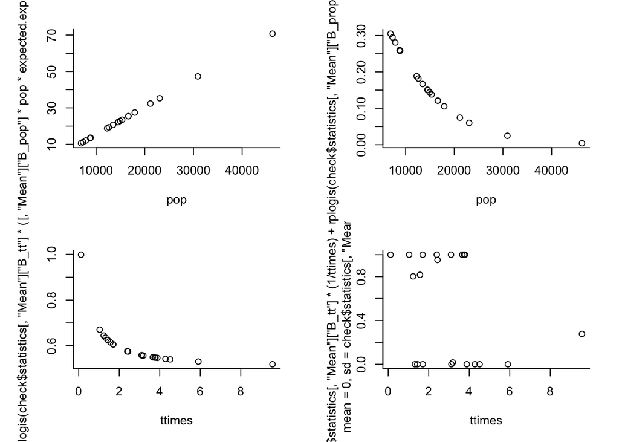

```r
## parameter estimates
par(mfrow = c(2, 2), mar = c(5, 5, 2,  2))
plot(pop, (check$statistics[,"Mean"]["B_pop"]*pop*expected.exposures.mid)/(pop/1e5), bty = "l")
plot(pop, plogis(check$statistics[,"Mean"]["B_prop"]*pop), bty = "l")
plot(ttimes, plogis(check$statistics[,"Mean"]["B_tt"]*(1/ttimes)), bty = "l")
plot(ttimes, plogis(check$statistics[,"Mean"]["B_tt"]*(1/ttimes) + rnorm(length(ttimes), mean = 0,
                              sd = check$statistics[,"Mean"]["sd"])), bty = "l")
```

The scaling factor is not identifiable.

### Fixing at minimum scaling factor

```r
## model
tt.model <- "model {
  # reported bites
    for (j in 1:nlocs){
        # Number of bites
        bites[j] ~ dpois(rabid[j]*rho[j] + background[j] + B_0)
    }

  # spatial effects
  for (g in 1:nlocs){
    # Spatial random effect
    loc_eff[g] ~ dnorm(0, tau_loc)

    # Reporting in place g
    logit(rho[g]) <- B_tt*(1/ttimes[g]) + loc_eff[g]

    # Incidence avg in place g
    scaling.factor[g] <- B_pop*pop[g]
    rabid[g] <- scaling.factor[g]*expected.mean[g]

    # Background avg in place g
    logit(p_rabid[g]) <- B_prop*pop[g]
    background[g] <- (rabid[g]*rho[g])/p_rabid[g] - rabid[g]
  }

  tau_loc <- 1/sd

  # priors
  B_tt ~ dnorm(0, 0.1)
  sd ~ dunif(0, 100)
  B_prop ~ dnorm(0, 0.1)
  B_0 ~ dnorm(0, 0.1)
}"

## data
nlocs = length(bites)

data <- list (bites = bites, pop = moramanga$commune.midpops,
              expected.mean = expected.exposures.mid,
              B_pop = B_pop.min, ttimes = ttimes, nlocs = nlocs)

inits <- list(B_tt = rnorm(1, 0, 1e-6), sd = 5,
              B_prop = rnorm(1, 0, 1e-6),
              B_0 = rnorm(1, 0, 1e-6))

jags_mod <- jags.model(textConnection(tt.model), data = data, inits = inits, n.chains = 5,
                       n.adapt = 1000)
params <- c("B_tt", "sd", "B_prop", "B_0")

samps <- coda.samples(jags_mod, params, n.iter = 10000)
burn.in <- 5000
summary(window(samps, start = burn.in))
```

```
##
## Iterations = 5000:11000
## Thinning interval = 1
## Number of chains = 5
## Sample size per chain = 6001
##
## 1. Empirical mean and standard deviation for each variable,
##    plus standard error of the mean:
##
##              Mean        SD  Naive SE Time-series SE
## B_0     2.6693019 9.301e-01 5.370e-03      2.429e-02
## B_prop -0.0001253 1.451e-05 8.378e-08      1.849e-06
## B_tt    0.7520183 7.948e-01 4.589e-03      5.622e-02
## sd     10.5047103 8.400e+00 4.849e-02      2.566e-01
##
## 2. Quantiles for each variable:
##
##              2.5%        25%        50%        75%      97.5%
## B_0     0.8822367  2.0498208  2.6486807  3.2629137  4.5921629
## B_prop -0.0001526 -0.0001351 -0.0001253 -0.0001159 -0.0000962
## B_tt   -0.3598395  0.2028115  0.6068452  1.1167928  2.8296901
## sd      2.8520293  5.4813233  8.0958967 12.5326478 32.7289326
```

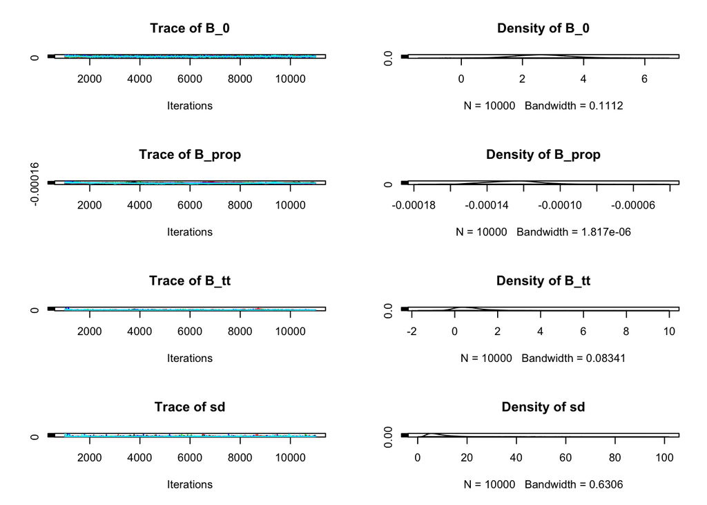

```r
plot(samps)
```

```r
# gelman.plot(samps)
gelman.diag(samps)
```

```
## Potential scale reduction factors:
##
##        Point est. Upper C.I.
## B_0          1.00       1.01
## B_prop       1.04       1.09
## B_tt         1.05       1.10
## sd           1.03       1.05
##
## Multivariate psrf
##
## 1.04
```

```r
samps <- coda.samples(jags_mod, params, n.iter = 10000)
burn.in <- 5000
check <- summary(window(samps, start = burn.in))
check
```

```
##
## Iterations = 11001:21000
## Thinning interval = 1
## Number of chains = 5
## Sample size per chain = 10000
##
## 1. Empirical mean and standard deviation for each variable,
##    plus standard error of the mean:
##
##              Mean        SD  Naive SE Time-series SE
## B_0     2.5801583 9.400e-01 4.204e-03      2.093e-02
## B_prop -0.0001287 1.541e-05 6.893e-08      1.591e-06
## B_tt    0.6751683 8.042e-01 3.596e-03      4.590e-02
## sd      9.8917463 7.406e+00 3.312e-02      1.694e-01
##
## 2. Quantiles for each variable:
##
##              2.5%        25%        50%        75%      97.5%
## B_0     0.8246009  1.9364412  2.5476141  3.1857223  4.545e+00
## B_prop -0.0001552 -0.0001396 -0.0001298 -0.0001195 -9.529e-05
## B_tt   -0.4114126  0.1496985  0.4983035  1.0020494  2.891e+00
## sd      2.8788867  5.4168019  7.8184563 11.8542688  2.956e+01
```

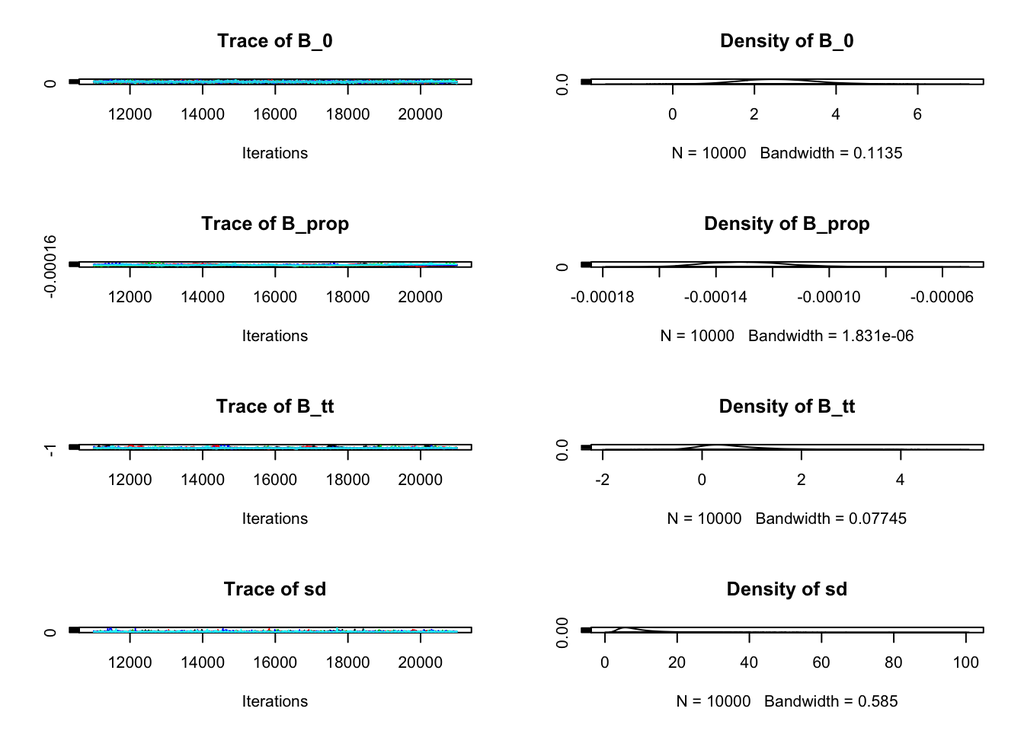

```r
plot(samps)
```

```r
# gelman.plot(samps)
gelman.diag(samps)
```

```
## Potential scale reduction factors:
##
##        Point est. Upper C.I.
## B_0          1.01       1.01
## B_prop       1.04       1.10
## B_tt         1.01       1.03
## sd           1.00       1.00
##
## Multivariate psrf
##
## 1.05
```

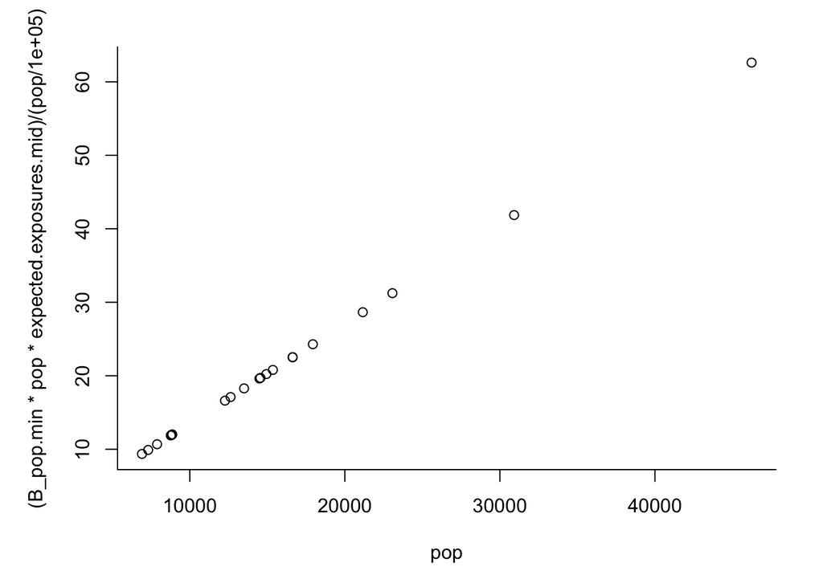

```r
## parameter estimates
par(mfrow = c(1, 1), mar = c(5, 5, 2,  2))
plot(pop, (B_pop.min*pop*expected.exposures.mid)/(pop/1e5), bty = "l")
```

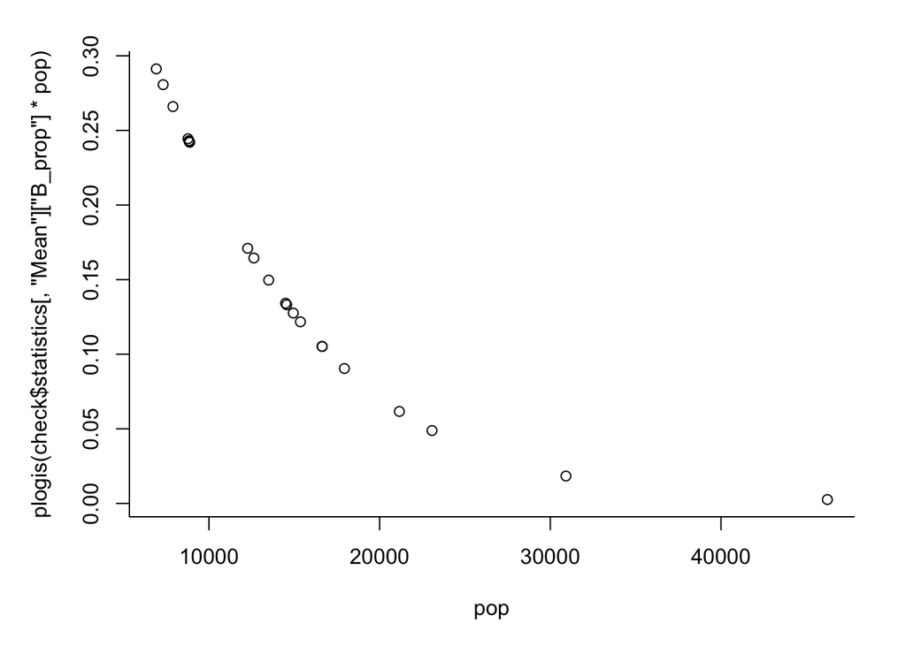

```r
plot(pop, plogis(check$statistics[,"Mean"]["B_prop"]*pop), bty = "l")
```

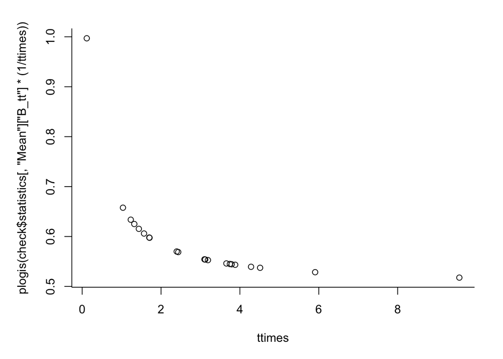

```r
plot(ttimes, plogis(check$statistics[,"Mean"]["B_tt"]*(1/ttimes)), bty = "l")
```

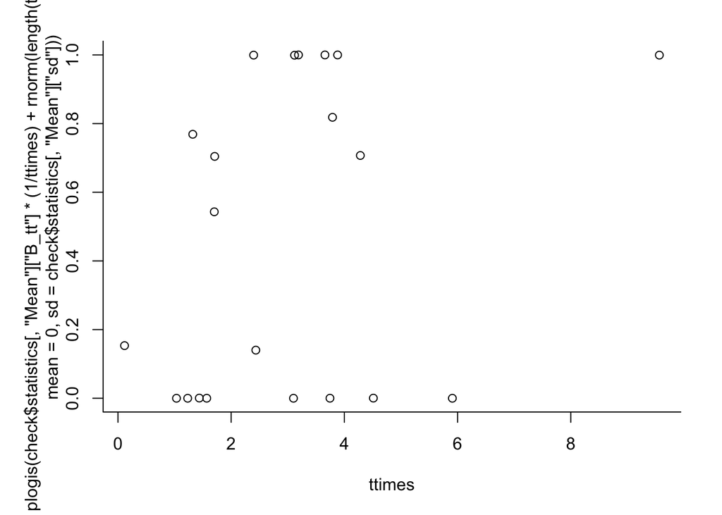

```r
plot(ttimes, plogis(check$statistics[,"Mean"]["B_tt"]*(1/ttimes) + rnorm(length(ttimes), mean = 0,
                              sd = check$statistics[,"Mean"]["sd"])), bty = "l")
```

### Fixing at maximum scaling factor

```r
## model
tt.model <- "model {
  # reported bites
    for (j in 1:nlocs){
        # Number of bites
        bites[j] ~ dpois(rabid[j]*rho[j] + background[j] + B_0)
    }

  # spatial effects
  for (g in 1:nlocs){
    # Spatial random effect
    loc_eff[g] ~ dnorm(0, tau_loc)

    # Reporting in place g
    logit(rho[g]) <- B_tt*(1/ttimes[g]) + loc_eff[g]

    # Incidence avg in place g
    scaling.factor[g] <- B_pop*pop[g]
    rabid[g] <- scaling.factor[g]*expected.mean[g]

    # Background avg in place g
    logit(p_rabid[g]) <- B_prop*pop[g]
    background[g] <- (rabid[g]*rho[g])/p_rabid[g] - rabid[g]
  }

  tau_loc <- 1/sd

  # priors
  B_tt ~ dnorm(0, 0.1)
  sd ~ dunif(0, 100)
  B_prop ~ dnorm(0, 0.1)
  B_0 ~ dnorm(0, 0.1)
}"

## data
nlocs = length(bites)

data <- list (bites = bites, pop = moramanga$commune.midpops,
              expected.mean = expected.exposures.mid,
              B_pop = B_pop.max, ttimes = ttimes, nlocs = nlocs)

inits <- list(B_tt = rnorm(1, 0, 1e-6), sd = 5,
              B_prop = rnorm(1, 0, 1e-6),
              B_0 = rnorm(1, 0, 1e-6))

jags_mod <- jags.model(textConnection(tt.model), data = data, inits = inits, n.chains = 5,
                       n.adapt = 1000)
params <- c("B_tt", "sd", "B_prop", "B_0")

samps <- coda.samples(jags_mod, params, n.iter = 10000)
burn.in <- 5000
summary(window(samps, start = burn.in))
```

```
##
## Iterations = 5000:11000
## Thinning interval = 1
## Number of chains = 5
## Sample size per chain = 6001
##
## 1. Empirical mean and standard deviation for each variable,
##    plus standard error of the mean:
##
##              Mean        SD  Naive SE Time-series SE
## B_0     2.5831790 9.723e-01 5.613e-03      2.754e-02
## B_prop -0.0001055 1.767e-05 1.020e-07      2.515e-06
## B_tt    0.6623333 6.776e-01 3.912e-03      4.251e-02
## sd      7.3670375 6.072e+00 3.505e-02      2.011e-01
##
## 2. Quantiles for each variable:
##
##              2.5%        25%        50%        75%      97.5%
## B_0     0.7175906  1.9246066  2.5597670  3.215e+00  4.5517941
## B_prop -0.0001403 -0.0001173 -0.0001056 -9.324e-05 -0.0000717
## B_tt   -0.2946534  0.1945919  0.5333052  9.952e-01  2.3730981
## sd      1.9865574  3.8981654  5.6984527  8.664e+00 23.7184453
```

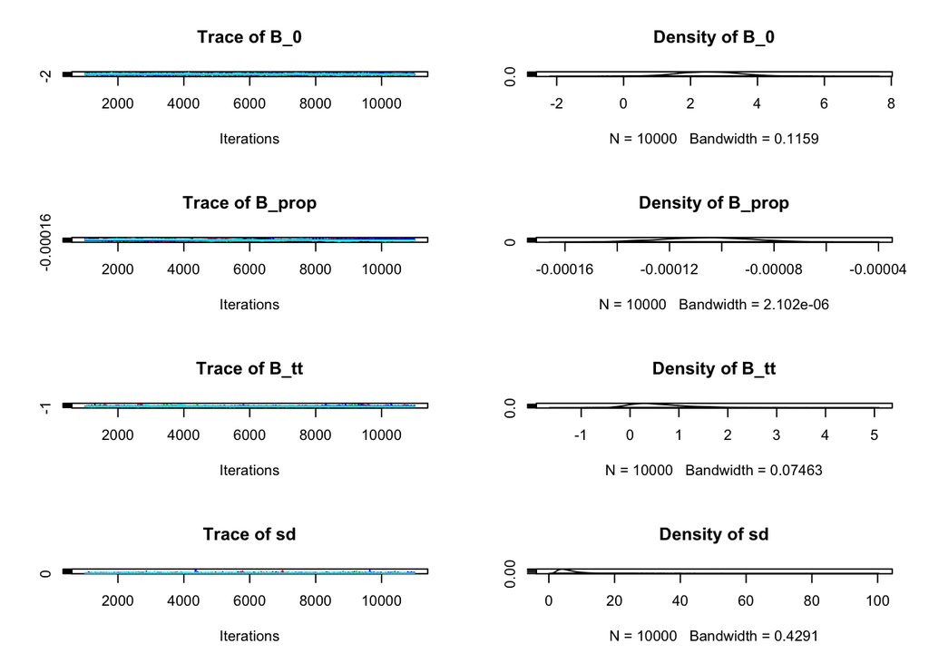

```r
plot(samps)
```

```r
# gelman.plot(samps)
gelman.diag(samps)
```

```
## Potential scale reduction factors:
##
##        Point est. Upper C.I.
## B_0          1.01       1.02
## B_prop       1.11       1.28
## B_tt         1.07       1.16
## sd           1.03       1.06
##
## Multivariate psrf
##
## 1.11
```

```r
samps <- coda.samples(jags_mod, params, n.iter = 10000)
burn.in <- 5000
check <- summary(window(samps, start = burn.in))
check
```

```
##
## Iterations = 11001:21000
## Thinning interval = 1
## Number of chains = 5
## Sample size per chain = 10000
##
## 1. Empirical mean and standard deviation for each variable,
##    plus standard error of the mean:
##
##              Mean        SD  Naive SE Time-series SE
## B_0     2.5008632 9.454e-01 4.228e-03      1.806e-02
## B_prop -0.0001098 1.418e-05 6.342e-08      1.411e-06
## B_tt    0.6524257 7.080e-01 3.166e-03      3.496e-02
## sd      7.2734186 5.505e+00 2.462e-02      1.222e-01
##
## 2. Quantiles for each variable:
##
##              2.5%        25%        50%        75%      97.5%
## B_0     0.7443253  1.8521574  2.4617934  3.1216002  4.435e+00
## B_prop -0.0001385 -0.0001191 -0.0001094 -0.0001001 -8.288e-05
## B_tt   -0.3610558  0.1776463  0.5123883  0.9763078  2.527e+00
## sd      2.1076052  3.9439314  5.7342500  8.6580459  2.208e+01
```

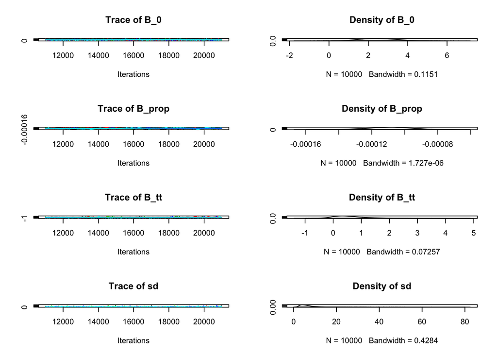

```r
plot(samps)
```

```r
# gelman.plot(samps)
gelman.diag(samps)
```

```
## Potential scale reduction factors:
##
##        Point est. Upper C.I.
## B_0          1.00       1.01
## B_prop       1.03       1.07
## B_tt         1.02       1.05
## sd           1.01       1.02
##
## Multivariate psrf
##
## 1.02
```

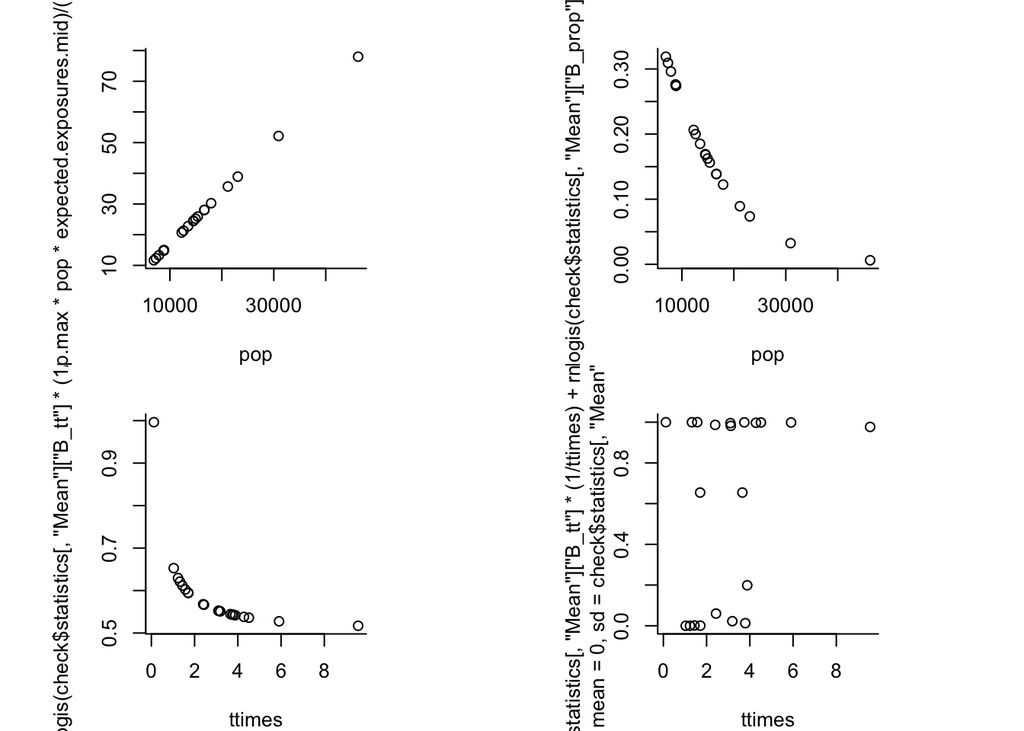

```r
## parameter estimates
par(mfrow = c(2, 2), mar = c(4, 6, 2, 6))
plot(pop, (B_pop.max*pop*expected.exposures.mid)/(pop/1e5), bty = "l")
plot(pop, plogis(check$statistics[,"Mean"]["B_prop"]*pop), bty = "l")
plot(ttimes, plogis(check$statistics[,"Mean"]["B_tt"]*(1/ttimes)), bty = "l")
plot(ttimes, plogis(check$statistics[,"Mean"]["B_tt"]*(1/ttimes) + rnorm(length(ttimes), mean = 0,
                              sd = check$statistics[,"Mean"]["sd"])), bty = "l")
```

```r
# ## model
# tt.model <- "model {
#   # reported bites
#   for (t in 1:ntimes){
#     for (j in 1:nlocs){
#         # Number of bites
#         bites[j, t] ~ dpois(rabid[j]*rho[j] + background[j] + B_0)
#     }
#   }
#
#   # spatial effects
#   for (g in 1:nlocs){
#     # Spatial random effect
#     loc_eff[g] ~ dnorm(0, tau_loc)
#
#     # Reporting in place g
#     logit(rho[g]) <- B_tt*(1/ttimes[g]) + loc_eff[g]
#
#     # Incidence avg in place g
#     scaling.factor[g] <- B_pop*pop[g]
#     rabid[g] <- scaling.factor[g]*expected.mean[g]
#
#     # Background avg in place g
#     p_rabid[g] <- ifelse(rabid[g]/avg.reported[g]*0.9 >= p_rabid_max,
#                               p_rabid_max, rabid[g]/avg.reported[g]*0.9)
#     background[g] <- rabid[g]/p_rabid[g] - rabid[g]
#   }
#
#   tau_loc <- 1/sd
#
#   # priors
#   B_tt ~ dnorm(0, 0.01)
#   sd ~ dunif(0, 100)
#   B_pop ~ dunif(B_pop.min, B_pop.max)
#   B_0 ~ dnorm(0, 0.01)
# }"

# ## data
# ntimes = ncol(bites)
# nlocs = nrow(bites)
#
# data <- list (bites = bites, pop = moramanga$commune.midpops,
#               expected.mean = expected.exposures.mid, avg.reported = moramanga$monthly.bites,
#               p_rabid_max = 0.9, B_pop.min = B_pop.min, B_pop.max = B_pop.max,
#               ttimes = ttimes, ntimes = ntimes , nlocs = nlocs)
#
# inits <- list(B_tt = rnorm(1, 0, 1e-6), sd = 1,
#               B_pop = rnorm(1, (B_pop.max + B_pop.min)/2, 1e-6))
#
# jags_mod <- jags.model(textConnection(tt.model), data = data, inits = inits, n.chains = 10, n.adapt = 1000)
#
# params <- c("B_tt", "sd", "B_pop")
#
# samps <- coda.samples(jags_mod, params, n.iter = 10000)
# burn.in <- 5000
# summary(window(samps, start = burn.in))
# plot(samps)
# gelman.plot(samps)
# gelman.diag(samps)
```